# Workshop 2

Filip Mellgren, David Hakula, Christopher Hayes

2019-04-10

## R Markdown

```r
df <- import("Hypermarkets.dta")
df <- df %>% as_tibble %>% drop_na()
```

# Question 1. Premises of the analysis

There are several pros and cons of using only big-box stores rather than all stores in this type of market entry analysis. The perhaps most important (but not the only) pros are:

• Sharper focus of the analysis - The analysis focuses on an important aspect of competition; it might be the case that the market constrained to big-box stores behaves differently than a market including all types of store.

• Richer model: Following the sharper focus, a more narrow approach allows for a richer model of competition and profitability.

Of course, restricting the analysis to only big-box stores also comes with a downside. Some of the cons are:

• Higher risk of missing crucial aspects – A more limited analysis might fail to take into account crucial aspects of competition; if smaller stores are competing in the same market, leaving those out of the analysis might lead to severe strategic mistakes.

• Not context specific – Leaving out other types of stores might give a skew the context that is implicitly built into models, biasing the estimates if we are unable to find the right control variables.

When it comes to the question of whether there actually is a separate market for big-box stores, we have to rely on reason and assumption; we lack the data needed to make more sophisticated analyses (such as price analysis, estimation of substitution effects or a hypothetical monopolist test such as the SSNIP-test).

From our point of view, the separate market assumption is not strictly plausible, but is prohibitively restrictive analytically. There are several reasons for this:

• Qualitative evidence is of substantial but inexhaustive overlap between the services offered by big-box retailers and by ‘small-box’ (plausible substitutes based on characteristics and intended use). Within this overlap there is underlap between the different constituent small retailers. Furthermore, big-boxes have distinct characteristics they don’t share with smaller stores, offering convenience and scale economies.

• Natural experiments in the US also show substitution both on the demand side and in the labour market. Haltiwanger, Jarmin & Krizan 2009 find big box entry reduces employment growth in both single unit and small chain retailers, but only with both immediate area and detailed industry in common. (https://www2.census.gov/ces/wp/2009/CES-WP-09-34.pdf) Similarly, Dube, Lester & Eidlin 2007 found lower average and aggregate retail worker earnings associated with Walmart’s entry into a county.

Hence, we can move forward with the analysis.

# Question 2. Distribution of big box stores

Chris Show the distribution of the number of big-box stores across local markets (BR Table 2). Comment.

```r
library(stargazer)
# TODO: make latex ready
df %>% group_by(stores) %>%
  summarise(n = n()) %>% mutate(freq = n/ sum(n), cum = cumsum(n)/sum(n)) %>%
  t() %>% round(2) %>% stargazer(title = "Distribution of stores", type = "text") # change from text to latex
```

# Distribution of stores

stores 0 1 2 3 4 5  
n 21 46 57 38 22 51  
freq 0.090 0.200 0.240 0.160 0.090 0.220 cum 0.090 0.290 0.530 0.690 0.780 1  
——————————————

The distribution of the number of big-box stores across local markets is bimodal, with peaks at 2 and 5. More than half of municipalities in our data have 2 or fewer big box retailers, while 9% have none at all. 22% have the maximum observed value of 5.

# Question 3. Graphically illustrate relationship

Filip

Graphically illustrate the relationship between population and the number of stores in local markets. Moreover, show a histogram of local market population across markets with different number of hypermarkets

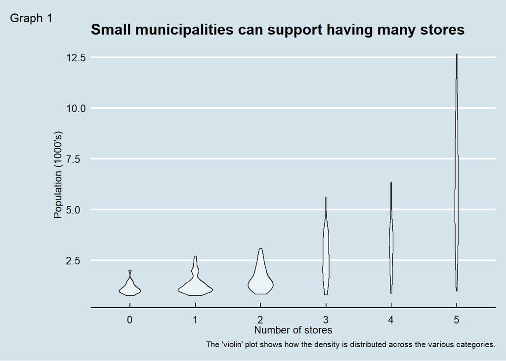

```r
  df %>% ggplot(aes(x = factor(stores), y = pop)) +
  geom_violin(alpha=0.5, scale = "count", adjust = 1) +
  theme_economist() + scale_fill_economist() + scale_color_economist() +
  labs(title = "Small municipalities can support having many stores",
       caption = "The 'violin' plot shows how the density is distributed across the various categories.",
  tag = "Graph 1", x = "Number of stores", y = "Population (1000's)",
  color = "Stores", fill = "Stores")
```

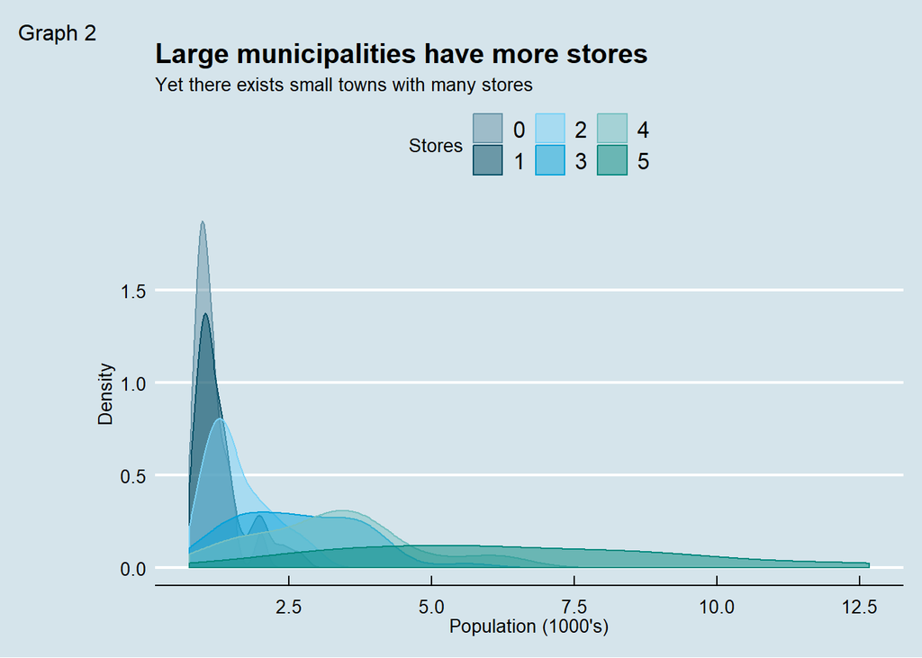

```r
df %>% ggplot(aes(x = pop, fill = as.character(stores),
                  color = as.character(stores) )) +
  geom_density(alpha=0.5) + scale_fill_economist() + scale_color_economist() +
  theme_economist() +
  labs(title = "Large municipalities have more stores",
       subtitle = "Yet there exists small towns with many stores",
  tag = "Graph 2", x = "Population (1000's)", y = "Density",
  color = "Stores", fill = "Stores")
```

```r
word_margin <- 6
ggsave("Store_density_plot.png", height = 10, width = 29.7 - word_margin, units = "cm")
```

# Question 4 summary stats and descriptives

David Present summary statistics and correlations of the number of stores and local market characteristics. Interpret your findings.

```r
# TODO: make latex ready

df <- as_tibble(df)

# Begin by doing some feature engineering:
df <- df %>% mutate(close_pop = dist * pop,
              cons_pc = consumption/pop,
              cons_share = cons_pc/wage)

# pos_gpop and neg_gpop not included
summary_df <- sapply(dplyr::select(df, everything()), summary)%>% t() %>% round(2) %>%
  as_tibble(rownames = "Variable") %>% dplyr::select("Variable","Min.", "Mean", "Max.")

sd_df <- df %>% map(function(x) sd(x)) %>% as_tibble() %>% t() %>%
  round(2) %>% as_tibble(rownames = "Variable") %>% rename ("Std. Dev" = V1)
corr_df <- df %>% map(function(x) cor(df$stores, x)) %>%
  as_tibble() %>% t() %>% round(2) %>% as_tibble(rownames = "Variable") %>%
  rename("Correlation w. stores" = V1)


summary_df <- full_join(summary_df, sd_df) %>% full_join(corr_df)
xtable::xtable(summary_df)
```

| Variable | Min. | Mean | Max. | Std. Dev | Correlation w. stores |
| --- | --- | --- | --- | --- | --- |
| stores | 0.00 | 2.63 | 5.00 | 1.63 | 1.00 |
| pop | 0.75 | 2.84 | 12.67 | 2.46 | 0.72 |
| gpop | -0.09 | 0.02 | 0.23 | 0.05 | 0.28 |
| pos_gpop | 0.00 | 0.03 | 0.23 | 0.04 | 0.21 |
| neg_gpop | -0.09 | -0.01 | 0.00 | 0.02 | 0.30 |
| s_kids | 0.08 | 0.11 | 0.16 | 0.02 | 0.12 |
| s_pens | 0.12 | 0.20 | 0.27 | 0.03 | -0.24 |
| s_young | 0.06 | 0.10 | 0.22 | 0.02 | 0.54 |
| s_women | 0.48 | 0.50 | 0.53 | 0.01 | 0.51 |
| consumption | 1.68 | 6.76 | 30.02 | 5.91 | 0.72 |
| hprice | 0.25 | 1.21 | 4.71 | 0.76 | 0.30 |
| hsold | 0.13 | 2.20 | 9.68 | 1.61 | 0.68 |
| wage | 2.17 | 2.30 | 2.59 | 0.07 | 0.32 |
| dist | 0.45 | 0.75 | 1.00 | 0.11 | 0.38 |
| close_pop | 0.40 | 2.26 | 11.73 | 2.20 | 0.71 |
| cons_pc | 2.15 | 2.35 | 3.55 | 0.13 | 0.18 |
| cons_share | 0.92 | 1.02 | 1.47 | 0.05 | 0.02 |

From the table, we draw several interesting observations of the data:

• The stores variable has it maximum at 5. This implies that either no municipality has more than five big-box stores, or that larger number has been coded as five in the present data set.

• The variables that correlates strongest with number of stores are population (0.72) and consumption (0.72). Hence, more populous areas where people with higher purchasing live have more stores. Other variables that correlate strongly with number of stores are the share of population living close the stores (0.71) [should this really be used?], the number of houses sold (0.68) and the share of young people (0.54).

[Comments: - I think we should look into the consumption and consumption per capita variables again. Are we sure?]

# Question 5 Variables included in the analysis

Our preferred specification is obtained through following the type of reasoning used by Bresnahan & Reiss 1991. The model constructs a profit formula by relating the available variables into three separate models – market size, variable profits, and fixed costs. Variable profits and fixed costs are both parametrized such that margins are falling in the number of firms. Given the data set at hand, we land the in following setup:

To determine the market size S, we include the following variables in the population variables vector Y: population (pop), positive population growth (pos_gpop) and negative population growth (neg_gpop). We choose to include both positive and negative growth, as there may be non-linearity present. Note that we leave out the variable gpop to avoid perfect collinearity.

To determine the variable profits V, we include the following variables in the local market characteristics vector X: share of kids (s_kids), share of pensioners (s_pens), share of young people (s_young), share of women (s_women) and consumption per capita (cons_pc). We choose to include these as the variable profits are likely to be dependent of population’s composition and characteristics, to the extent such details bear on how much the population will buy from big box retailers. We also include the consumption per capita to capture the willingness to spend.

[We do *not* include wage here?]

To determine the fixed costs F, we include the following variables in the (fixed) cost shifters vector W: average price per square-meter of houses sold (hprice), and the average monthly wage (wage). We include the average price per square-meter of houses sold as it functions as a proxy that captures the cost of buying the facility. The average monthly wage captures the fixed costs associated with staffing the stores.

Note that we choose to not use the share of population with a store within 2 kilometers (dist), as it might function as a bad control: it is likely to be determined by the dependent variable in the profit equation.

# Question 6 ordered_probit script file

Filip (table) Chris Specify and estimate the entry model by BR (1991) using the available data. The do-file “BR Estim.do” is available on the course web page. Discuss your results (BR Table 4).

Do file with the estimateion. Ordered probit, what’s the probability to observe 1, 2, 3 ,etc… Important to specify probabilities to plug into likelihood function and plugginf in parameters that maximise probaility of observing the data.

Store in market if profit larger than 0. Observed variable is whether town in store, i.e. profit > 0. The latent variable is the profit which we don’t observe.

Values she got: pop: 1.36 and hprice: -.267 cons: .42

Note, these might have been an ordinary probit, as she spoke about the ordered probit only later.

Ordered probit “Standard notes” from any text book in econometrics

Bresnahan and Reiss version. Slide 22 lecture 3 entry and market structure. Profit decrease in n. Latent varibale is $\pi_n = - \beta x - \alpha_n$. y is number of stores. $Pr(N = 0 \vert x) = Pr(\beta x - \alpha_1 + \varepsilon < 0) = 1 - \Phi(\bar{\pi_1})$ $Pr(N = 1 \vert x) = Pr(\beta x - \alpha_1 + \varepsilon > 0; \beta x - \alpha_2 + \varepsilon < 0) = \Phi(\bar{\pi}_1) - \Phi(\bar{\pi}_2)$.

gama fixed cost. Later entrants have higher fixed cost.

arguments: a1 to a5, g1 to g5, S V and F

Only a1 and g1 to calculate profit1. Then we add more and more for profit_,2,3,4,5.

$V = \alpha_1 + X \beta - \sum_{n = 2}^N \alpha_N: a_1 - a_5$ $F = \gamma_1 + \gamma_L W_L + \sum_{n = 2}^N \gamma_N: g1 - g5$

# Question 7 calculate entry thresholds

```r
# beta1*s_kids + beta2*s_young + beta3*s_pens+ beta4*s_women + beta5*cons_pc + beta6*wage
g1 <- 8.93
g2 <- 1.08
g3 <- 1.05
g4 <- 0.0695
g5 <- 0.359
a1 <- -3.62
a2 <- 0.0395
a3 <- 0.085
a4 <- 0.417
a5 <- 0.102
gL <- 0.37 # hprice
avg_hprice <- mean(df$hprice)
gL2 <- -3.81 # wages
avg_wage <- mean(df$wage)
beta1 <- -6.86 # fraction kids
avg_s_kids <- mean(df$s_kids)
beta2 <- -3.19 # fraction young
avg_s_young <- mean(df$s_young)
beta3 <- 0.213 # fraction pensioners
avg_s_pens <- mean(df$s_pens)
beta4 <- 12.5 # fraction women
avg_s_women <- mean(df$s_women)
beta5 <- -0.0882 # consumption per capita
avg_cons_pc <- mean(df$cons_pc)


S1 <- (g1 + gL* avg_hprice + gL2 * avg_wage) / (a1 + beta1*avg_s_kids + beta2*avg_s_young + beta3*avg_s_pens + beta4*avg_s_women + beta5*avg_cons_pc)
S2 <- (g1 + g2 + gL* avg_hprice + gL2 * avg_wage) / (a1 + beta1*avg_s_kids + beta2*avg_s_young + beta3*avg_s_pens + beta4*avg_s_women + beta5*avg_cons_pc - a2)
S3 <- (g1 + g2 + g3 + gL* avg_hprice + gL2 * avg_wage) / (a1 + beta1*avg_s_kids + beta2*avg_s_young + beta3*avg_s_pens + beta4*avg_s_women + beta5*avg_cons_pc - a2 - a3)
S4 <- (g1 + g2 + g3 + g4 + gL* avg_hprice + gL2 * avg_wage) / (a1 + beta1*avg_s_kids + beta2*avg_s_young + beta3*avg_s_pens + beta4*avg_s_women + beta5*avg_cons_pc - a2 - a3 - a4)
S5 <- (g1 + g2 + g3 + g4 + g5 + gL* avg_hprice + gL2 * avg_wage) / (a1 + beta1*avg_s_kids + beta2*avg_s_young + beta3*avg_s_pens + beta4*avg_s_women + beta5*avg_cons_pc - a2 - a3 - a4 - a5)
```